# 01_data_understanding

## Dataset Overview

The PaySim Fraud Detection dataset is a synthetic mobile money transactions dataset sourced from Kaggle.

It is designed to replicate real-world financial transaction behavior, including transfers, cash-outs, and payments, making it suitable for fraud detection analysis.

- The dataset simulates realistic transaction patterns
- It includes both normal and fraudulent transaction scenarios
- It is widely used for building and evaluating fraud detection models

```python
import pandas as pd
import numpy as np
import matplotlib.pyplot as plt
import seaborn as sns
```

```python
import pandas as pd

df = pd.read_excel("..C:\Users\USER\Financial-Crime-Analytics-Portfolio\project-1-fraud-detection\data\The Paysim Sample.xlsx")
df.head()
```

```
  Cell In[4], line 3
    df = pd.read_excel("..C:\Users\USER\Financial-Crime-Analytics-Portfolio\project-1-fraud-detection\data\The Paysim Sample.xlsx")
                       ^
SyntaxError: (unicode error) 'unicodeescape' codec can't decode bytes in position 4-5: truncated \UXXXXXXXX escape
```

```python
import pandas as pd

df = pd.read_excel("..C:\Users\USER\Financial-Crime-Analytics-Portfolio\project-1-fraud-detection\data\The Paysim Sample.xlsx")
df.head()
```

```
  Cell In[5], line 3
    df = pd.read_excel("..C:\Users\USER\Financial-Crime-Analytics-Portfolio\project-1-fraud-detection\data\The Paysim Sample.xlsx")
                       ^
SyntaxError: (unicode error) 'unicodeescape' codec can't decode bytes in position 4-5: truncated \UXXXXXXXX escape
```

```python
import pandas as pd

df = pd.read_excel(r"C:\Users\USER\Financial-Crime-Analytics-Portfolio\project-1-fraud-detection\data\The Paysim Sample.xlsx")
df.head()
```

|  | type | amount | nameOrig | oldbalanceOrg | newbalanceOrig | nameDest | oldbalanceDest | newbalanceDest | isFraud | isFlaggedFraud |
| --- | --- | --- | --- | --- | --- | --- | --- | --- | --- | --- |
| 0 | PAYMENT | 9839.64 | C1231006815 | 170136.0 | 160296.36 | M1979787155 | 0.0 | 0.0 | 0 | 0 |
| 1 | PAYMENT | 1864.28 | C1666544295 | 21249.0 | 19384.72 | M2044282225 | 0.0 | 0.0 | 0 | 0 |
| 2 | TRANSFER | 181.00 | C1305486145 | 181.0 | 0.00 | C553264065 | 0.0 | 0.0 | 1 | 0 |
| 3 | CASH_OUT | 181.00 | C840083671 | 181.0 | 0.00 | C38997010 | 21182.0 | 0.0 | 1 | 0 |
| 4 | PAYMENT | 11668.14 | C2048537720 | 41554.0 | 29885.86 | M1230701703 | 0.0 | 0.0 | 0 | 0 |

```python
df.shape
```

```
(1048575, 10)
```

```python
df.columns
df.info()
```

```
<class 'pandas.core.frame.DataFrame'>
RangeIndex: 1048575 entries, 0 to 1048574
Data columns (total 10 columns):
 #   Column          Non-Null Count    Dtype
---  ------          --------------    -----
 0   type            1048575 non-null  object
 1   amount          1048575 non-null  float64
 2   nameOrig        1048575 non-null  object
 3   oldbalanceOrg   1048575 non-null  float64
 4   newbalanceOrig  1048575 non-null  float64
 5   nameDest        1048575 non-null  object
 6   oldbalanceDest  1048575 non-null  float64
 7   newbalanceDest  1048575 non-null  float64
 8   isFraud         1048575 non-null  int64
 9   isFlaggedFraud  1048575 non-null  int64
dtypes: float64(5), int64(2), object(3)
memory usage: 80.0+ MB
```

```python
df.isnull().sum()
```

```
type              0
amount            0
nameOrig          0
oldbalanceOrg     0
newbalanceOrig    0
nameDest          0
oldbalanceDest    0
newbalanceDest    0
isFraud           0
isFlaggedFraud    0
dtype: int64
```

```python
df.duplicated().sum()
```

```
0
```

```python
df["isFraud"].value_counts()
df["isFraud"].value_counts(normalize=True) * 100
```

```
isFraud
0    99.89109
1     0.10891
Name: proportion, dtype: float64
```

```python
df["type"].value_counts()
```

```
type
CASH_OUT    373641
PAYMENT     353873
CASH_IN     227130
TRANSFER     86753
DEBIT         7178
Name: count, dtype: int64
```

```python
fraud_by_type = pd.crosstab(df["type"], df["isFraud"])
fraud_by_type
```

| isFraud type | 0 | 1 |
| --- | --- | --- |
| CASH_IN | 227130 | 0 |
| CASH_OUT | 373063 | 578 |
| DEBIT | 7178 | 0 |
| PAYMENT | 353873 | 0 |
| TRANSFER | 86189 | 564 |

[output not shown]

[output cut: 24 more lines]

[output not shown]

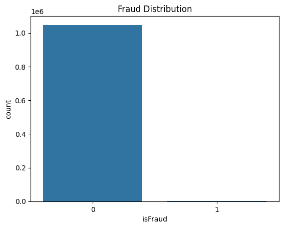

```python
sns.countplot(x="isFraud", data=df)
plt.title("Fraud Distribution")
plt.savefig("../outputs/fraud_distribution.png", bbox_inches="tight")
plt.show()
```

[output not shown]

[output cut: 24 more lines]

[output not shown]

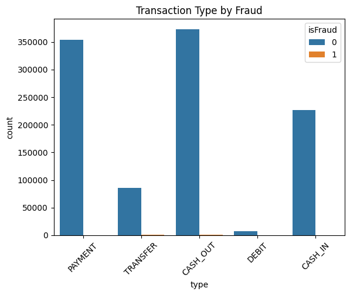

```python
sns.countplot(x="type", hue="isFraud", data=df)
plt.title("Transaction Type by Fraud")
plt.xticks(rotation=45)
plt.savefig("../outputs/transaction_type_by_fraud.png", bbox_inches="tight")
plt.show()
```

[output not shown]

[output cut: 24 more lines]

[output not shown]

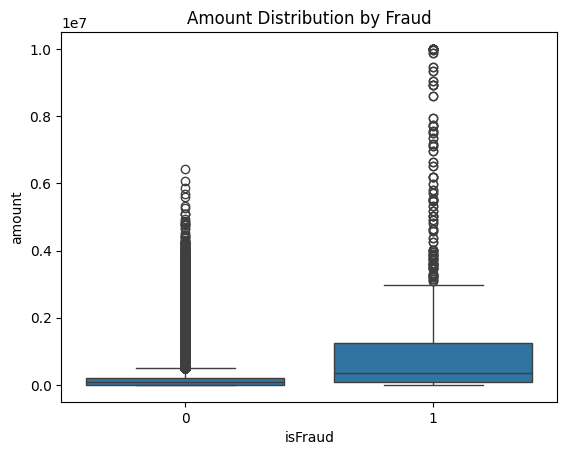

```python
sns.boxplot(x="isFraud", y="amount", data=df)
plt.title("Amount Distribution by Fraud")
plt.savefig("../outputs/amount_distribution_by_fraud.png", bbox_inches="tight")
plt.show()
```

### Business Questions & Answers

**How many transactions are fraud?** There are 1,142 fraudulent transactions in the dataset.

**Which transaction types are most risky?** Fraud occurs only in TRANSFER and CASH_OUT transactions, making them the most risky transaction types. No fraud was observed in PAYMENT, CASH_IN or DEBIT transactions.

**Are high-value transactions more likely to be fraud?** Yes, high-value transactions are more likely to be fraudulent. Fraud cases tend to involve significantly larger transaction amounts, with many extreme high-value outliers.

**Are fraud cases concentrated in certain patterns?** Yes, fraud is highly concentrated in specific patterns. It occurs only in TRANSFER and CASH_OUT transactions. These patterns suggest fraudsters focus on moving and withdrawing funds Other transaction types show no fraud activity